# Ejercicio5

Jesus Condor Torres

### Respuesta 5.a

En esta pregunta explicaremos lo que hace el siguiente codigo paso a paso, veamos a continuacion el codigo a ejecutarse paso a paso:

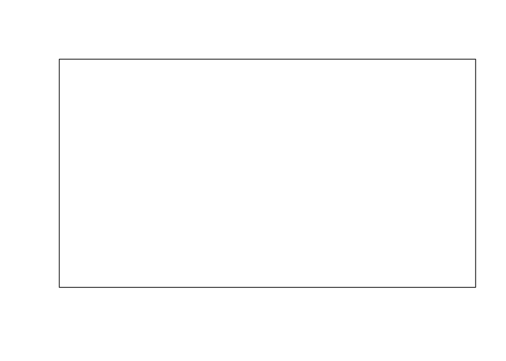

```r
plot.new()
plot.window(range(pressure$temperature), range(pressure$pressure))
box()
```

Esta funcion plot.new prepara un nuevo marco de graficos, tambien causa la finalizacion del un trazado grafico si estuviera en funcionamiento.

En esta parte la funcion plot.window configura el sistema de coordenadas para la nueva ventana de graficos compuesta por los datos de presion y temperatura con sus maximos y minimos valores obtenidos a partir de la funcion range y los datos a patir de las columnas temperature y pressure.

La funcion box dibuja un cuadro para el cual se dara el grafico que se desea obtener.

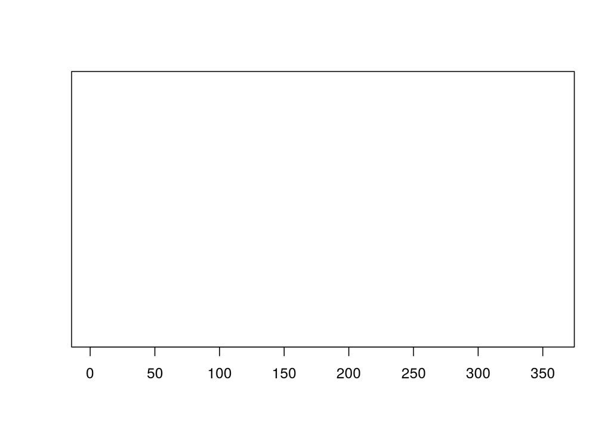

```r
plot.new()
plot.window(range(pressure$temperature), range(pressure$pressure))
box()
axis(1)
```

La funcion axis con el argumento 1 hace que se pongan los datos en las coordenadas del eje X.

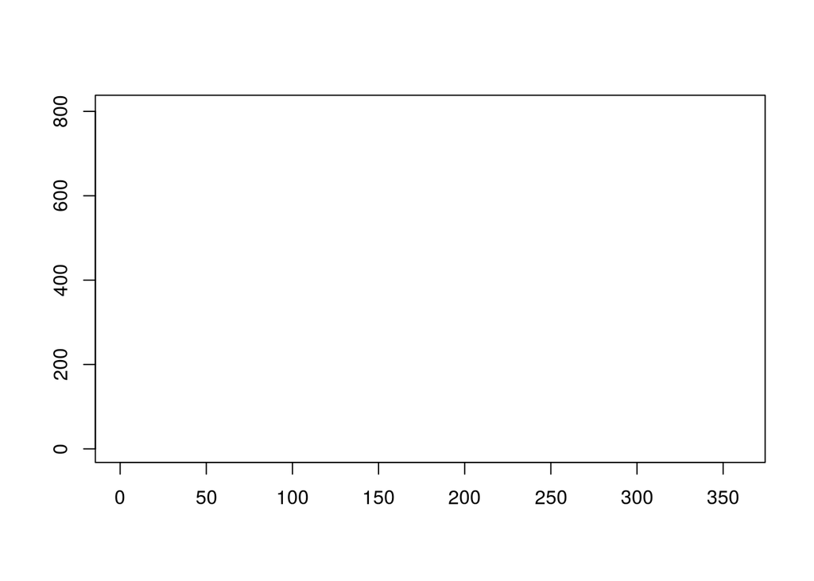

```r
plot.new()
plot.window(range(pressure$temperature), range(pressure$pressure))
box()
axis(1)
axis(2)
```

La siguiente funcion axis coen el argumento 2 hace que se pongan los datos en las coordenadas del eje Y.

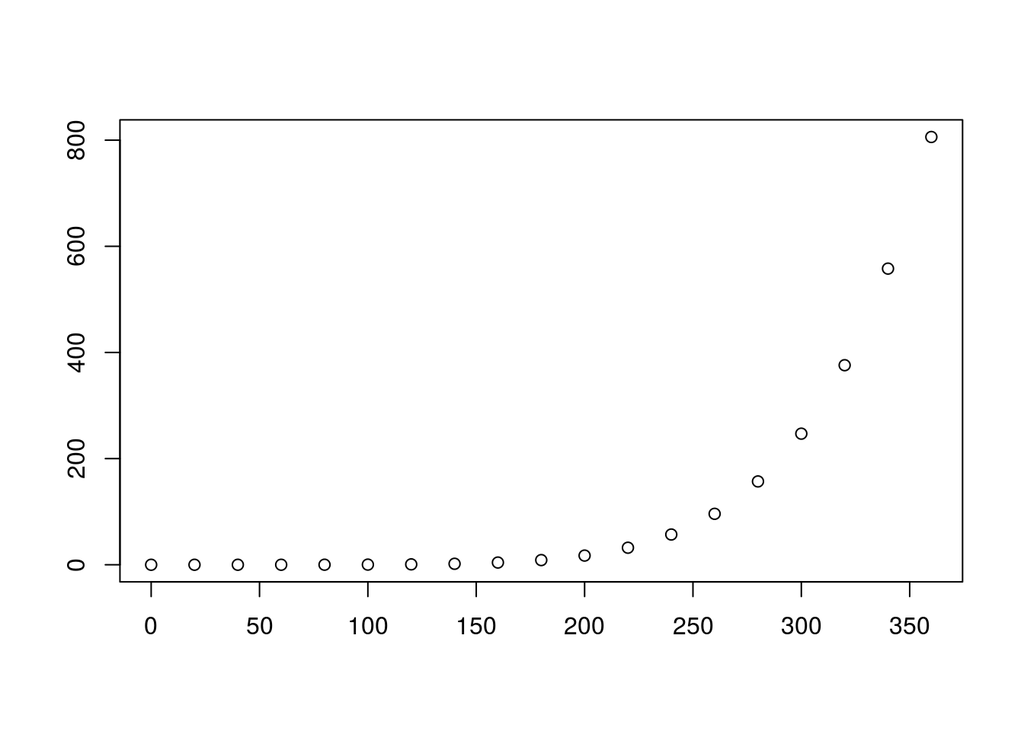

```r
plot.new()
plot.window(range(pressure$temperature), range(pressure$pressure))
box()
axis(1)
axis(2)
points(pressure$temperature, pressure$pressure)
```

Esta funcion points dibuja el comportamiento de la grafica a traves de puntos lo cual se puede apreciar en el grafico anterior.

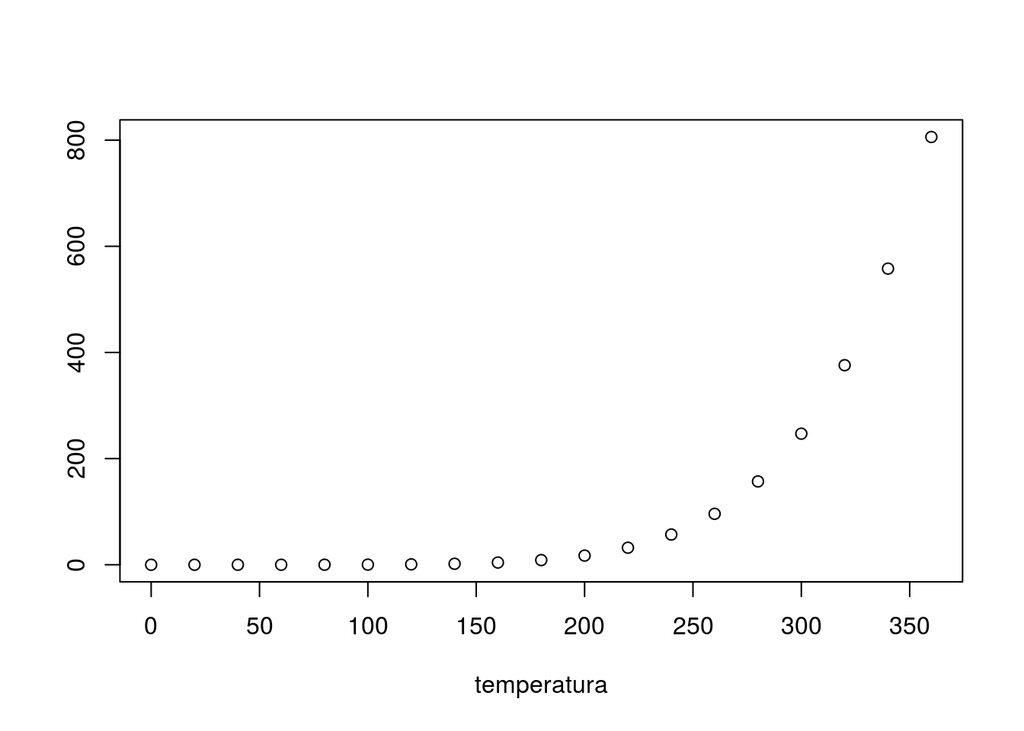

```r
plot.new()
plot.window(range(pressure$temperature), range(pressure$pressure))
box()
axis(1)
axis(2)
points(pressure$temperature, pressure$pressure)
mtext("temperatura", side = 1, line = 3)
```

La siguiente funcion mtext pone el subtitulo en el eje X con el nombre de temperatura.

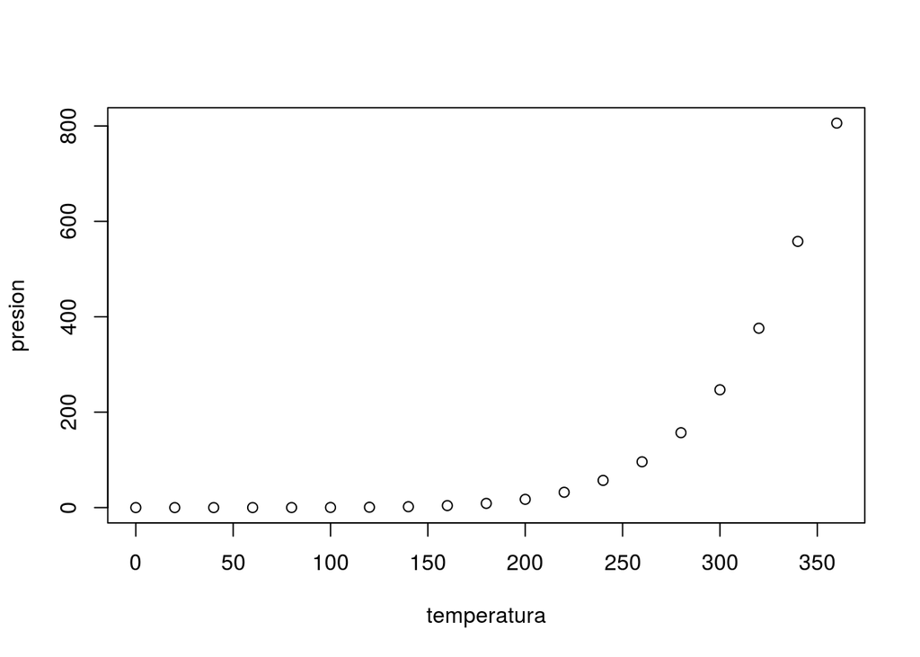

```r
plot.new()
plot.window(range(pressure$temperature), range(pressure$pressure))
box()
axis(1)
axis(2)
points(pressure$temperature, pressure$pressure)
mtext("temperatura", side = 1, line = 3)
mtext("presion", side = 2, line = 3)
```

Usando de nuevo la funcion mtext subtitulamos el eje Y por el nombre de presion.

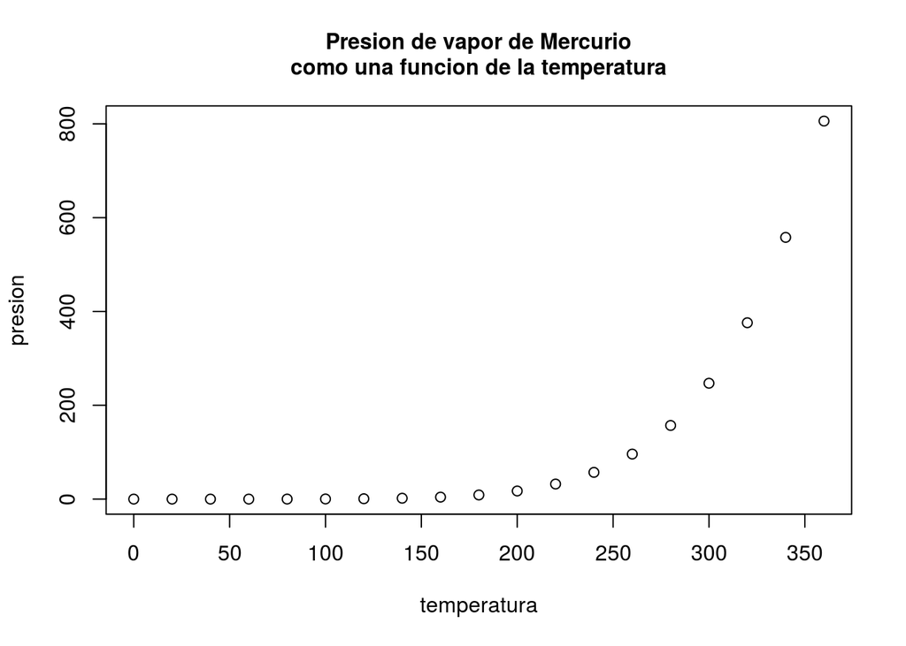

```r
plot.new()
plot.window(range(pressure$temperature), range(pressure$pressure))
box()
axis(1)
axis(2)
points(pressure$temperature, pressure$pressure)
mtext("temperatura", side = 1, line = 3)
mtext("presion", side = 2, line = 3)
mtext("Presion de vapor de Mercurio\ncomo una funcion de la temperatura",
       side = 3,line = 1, font = 2)
```

Finalmente la ultima funcion mtext pone el titulo principal de la grafica de nuestro codigo.

### Respuesta 5.b

En el segundo item haremos algo similar de la grafica del item a usando la funcion grid y explicaremos brevemente que es lo que hace cada funcion de grid.

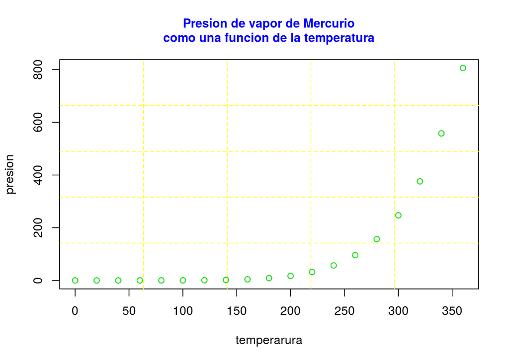

```r
plot.new() # Iniciando los marcos para un nuevo grafico
plot(pressure$temperature, pressure$pressure, xlab = "temperarura", ylab =    "presion") # Graficamos el marco y los subtitulos del eje X e Y
mtext("Presion de vapor de Mercurio\ncomo una funcion de la temperatura", side = 3, line = 1, font = 2, col = "blue" ) # Asignamos el titulo del grafico
grid(5, 5, lwd = 1, lty = 2, col = "yellow")
points(pressure$temperature, pressure$pressure, col = "green") # Insertamos los puntos de dispersion de la grafica
```

### Otros ejemplos de plot y grid

Modificaremos un poco el primer grafico con las mismas funciones del principio.

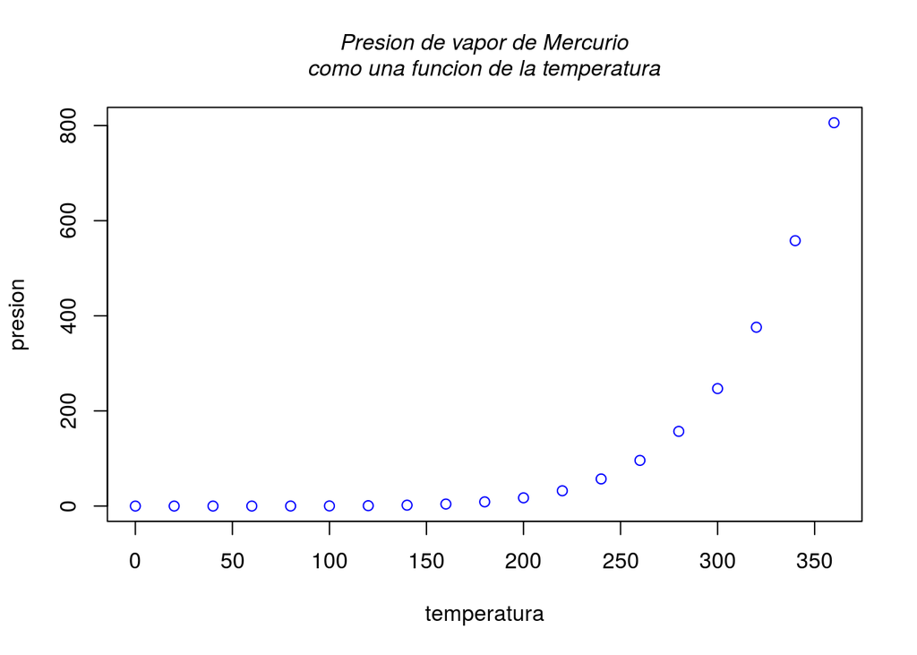

```r
plot.new()
plot.window(range(pressure$temperature), range(pressure$pressure))
box()
axis(1)
axis(2)
points(pressure$temperature, pressure$pressure, col = "blue")
mtext("temperatura", side = 1, line = 3, col = "black")
mtext("presion", side = 2, line = 3, col = "black")
mtext("Presion de vapor de Mercurio\ncomo una funcion de la temperatura", side = 3,line = 1, font = 3, col = "black")
```

#### Area de circulos

Ejemplo de usar la funcion *plot* haciendo una grafica en funcion del radio de una circunferencia, veremos a continuacion el comportamiento del area de la circunferencia en funcion del cambio del radio.

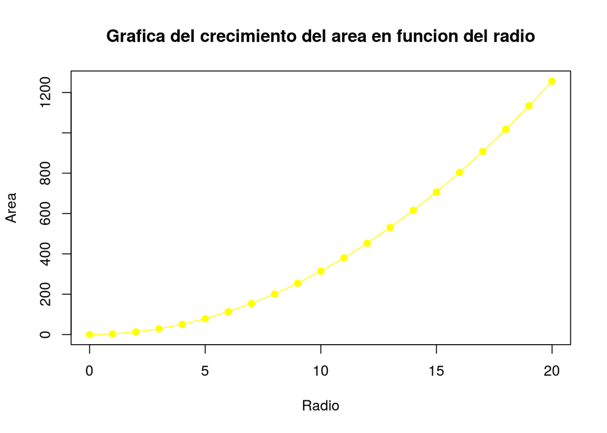

```r
radio <- 0:20 # Asigna a "radio"" valores enteros
area <- pi*radio^2 # Valores del area
plot(radio, area,   # (x,y) = (radio,area)
     type = "o",   # puntos y lineas
     main = "Grafica del crecimiento del area en funcion del radio",
     xlab = "Radio", # Etiqueta del eje x
     ylab = "Area", # Etiqueta del eje y
     col = "yellow", # color amarillo para la funcion
     pch = 19) # Tipo de punto
```

#### Grid

Ejemplo de como usar la funcion grid haciendo una grafica de funcion lineal en puntos.

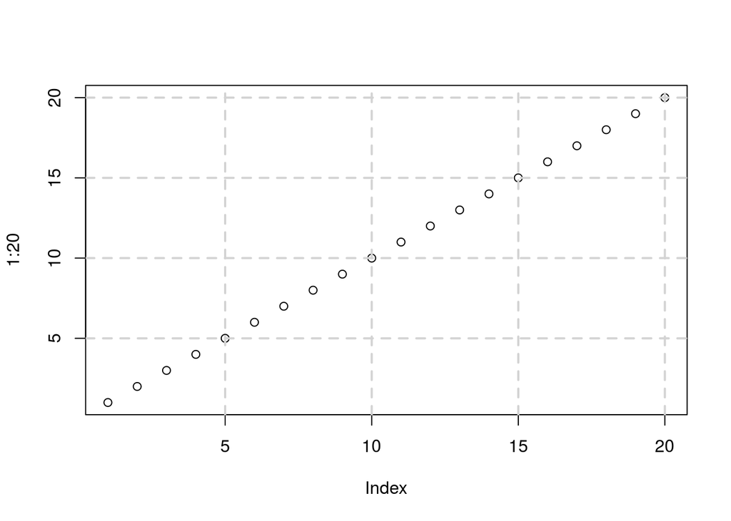

```r
plot(1:20) # grafica con datos del 1 al 100
grid(NULL, NULL, lwd = 2, lty = 2) # Lineas delineadas dentro del marco
```